# Lab3

```r
download.file("http://www.openintro.org/stat/data/kobe.RData", destfile =
"kobe.RData")
load("kobe.RData")
head(kobe)
```

```
##    vs game quarter time
## 1 ORL    1       1 9:47
## 2 ORL    1       1 9:07
## 3 ORL    1       1 8:11
## 4 ORL    1       1 7:41
## 5 ORL    1       1 7:03
## 6 ORL    1       1 6:01
##                                               description basket
## 1                 Kobe Bryant makes 4-foot two point shot      H
## 2                               Kobe Bryant misses jumper      M
## 3                        Kobe Bryant misses 7-foot jumper      M
## 4 Kobe Bryant makes 16-foot jumper (Derek Fisher assists)      H
## 5                         Kobe Bryant makes driving layup      H
## 6                               Kobe Bryant misses jumper      M
```

## R Markdown

```r
 kobe$basket[1:9]
```

```
## [1] "H" "M" "M" "H" "H" "M" "M" "M" "M"
```

### Exercise 1: What does a streak length of 1 mean (i.e., how many hits and misses are in astreak of 1)? What about a streak length of 0?

## Sreak of 1 means a H followed by a M. A streak of 0 is a M followed by a M/

### Exercise 2: Describe the distribution of Kobe’s streak lengths from the 2009 NBA finals.What was his typical streak length? How long was his longest streak of baskets?

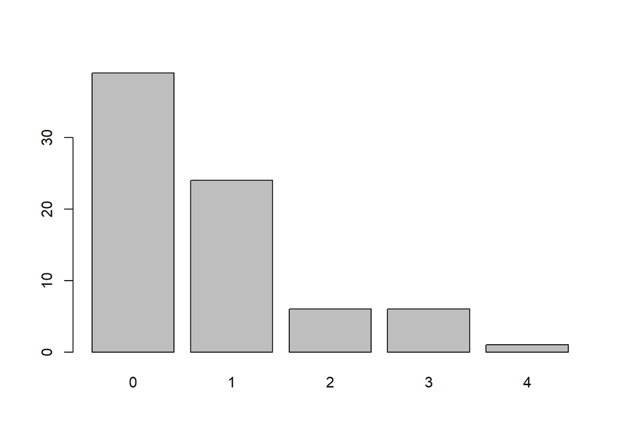

```r
kobe_streak <- calc_streak(kobe$basket)
barplot(table(kobe_streak))
```

##The distribution is right skewed.

```r
summary(kobe_streak)
```

```
##    Min. 1st Qu.  Median    Mean 3rd Qu.    Max.
##  0.0000  0.0000  0.0000  0.7632  1.0000  4.0000
```

## The typical streak is 0. The longest is 4.

### Exercise 3: In your simulation of flipping the unfair coin 100 times, how many flips came up heads?

```r
outcomes <- c("heads", "tails")
sim_unfair_coin <- sample(outcomes, size = 100, replace = TRUE, prob = c(0.2, 0.8))
table(sim_unfair_coin)["heads"]
```

```
## heads
##    19
```